# Risk Factor Analysis

## Outcome Variable

**Outcome Variable:** pers_wast

## Predictor Variables

**Intervention Variable:** nrooms

**Adjustment Set:**

- arm
- sex
- W_mage
- meducyrs
- feducyrs
- hhwealth_quart
- hfoodsec
- W_mhtcm
- W_nchldlt5
- W_parity
- impfloor
- impsan
- safeh20
- delta_W_mage
- delta_meducyrs
- delta_feducyrs
- delta_hhwealth_quart
- delta_hfoodsec
- delta_W_mhtcm
- delta_W_nchldlt5
- delta_W_parity
- delta_impfloor
- delta_impsan
- delta_safeh20

## Stratifying Variables

The analysis was stratified on these variable(s):

- agecat
- studyid
- country

## Data Summary

| agecat | studyid | country | nrooms | pers_wast | n_cell | n |
| --- | --- | --- | --- | --- | --- | --- |
| 0-24 months | ki0047075b-MAL-ED | BANGLADESH | 4+ | 0 | 9 | 242 |
| 0-24 months | ki0047075b-MAL-ED | BANGLADESH | 4+ | 1 | 3 | 242 |
| 0-24 months | ki0047075b-MAL-ED | BANGLADESH | 1 | 0 | 145 | 242 |
| 0-24 months | ki0047075b-MAL-ED | BANGLADESH | 1 | 1 | 7 | 242 |
| 0-24 months | ki0047075b-MAL-ED | BANGLADESH | 2 | 0 | 48 | 242 |
| 0-24 months | ki0047075b-MAL-ED | BANGLADESH | 2 | 1 | 2 | 242 |
| 0-24 months | ki0047075b-MAL-ED | BANGLADESH | 3 | 0 | 27 | 242 |
| 0-24 months | ki0047075b-MAL-ED | BANGLADESH | 3 | 1 | 1 | 242 |
| 0-24 months | ki0047075b-MAL-ED | BRAZIL | 4+ | 0 | 125 | 210 |
| 0-24 months | ki0047075b-MAL-ED | BRAZIL | 4+ | 1 | 2 | 210 |
| 0-24 months | ki0047075b-MAL-ED | BRAZIL | 1 | 0 | 4 | 210 |
| 0-24 months | ki0047075b-MAL-ED | BRAZIL | 1 | 1 | 0 | 210 |
| 0-24 months | ki0047075b-MAL-ED | BRAZIL | 2 | 0 | 20 | 210 |
| 0-24 months | ki0047075b-MAL-ED | BRAZIL | 2 | 1 | 0 | 210 |
| 0-24 months | ki0047075b-MAL-ED | BRAZIL | 3 | 0 | 59 | 210 |
| 0-24 months | ki0047075b-MAL-ED | BRAZIL | 3 | 1 | 0 | 210 |
| 0-24 months | ki0047075b-MAL-ED | INDIA | 4+ | 0 | 23 | 235 |
| 0-24 months | ki0047075b-MAL-ED | INDIA | 4+ | 1 | 2 | 235 |
| 0-24 months | ki0047075b-MAL-ED | INDIA | 1 | 0 | 78 | 235 |
| 0-24 months | ki0047075b-MAL-ED | INDIA | 1 | 1 | 6 | 235 |
| 0-24 months | ki0047075b-MAL-ED | INDIA | 2 | 0 | 72 | 235 |
| 0-24 months | ki0047075b-MAL-ED | INDIA | 2 | 1 | 6 | 235 |
| 0-24 months | ki0047075b-MAL-ED | INDIA | 3 | 0 | 42 | 235 |
| 0-24 months | ki0047075b-MAL-ED | INDIA | 3 | 1 | 6 | 235 |
| 0-24 months | ki0047075b-MAL-ED | NEPAL | 4+ | 0 | 129 | 236 |
| 0-24 months | ki0047075b-MAL-ED | NEPAL | 4+ | 1 | 2 | 236 |
| 0-24 months | ki0047075b-MAL-ED | NEPAL | 1 | 0 | 51 | 236 |
| 0-24 months | ki0047075b-MAL-ED | NEPAL | 1 | 1 | 1 | 236 |
| 0-24 months | ki0047075b-MAL-ED | NEPAL | 2 | 0 | 31 | 236 |
| 0-24 months | ki0047075b-MAL-ED | NEPAL | 2 | 1 | 0 | 236 |

[output cut: 338 more lines]

The following strata were considered:

- agecat: 0-24 months, studyid: ki0047075b-MAL-ED, country: BANGLADESH
- agecat: 0-24 months, studyid: ki0047075b-MAL-ED, country: BRAZIL
- agecat: 0-24 months, studyid: ki0047075b-MAL-ED, country: INDIA
- agecat: 0-24 months, studyid: ki0047075b-MAL-ED, country: NEPAL
- agecat: 0-24 months, studyid: ki0047075b-MAL-ED, country: PERU
- agecat: 0-24 months, studyid: ki0047075b-MAL-ED, country: SOUTH AFRICA
- agecat: 0-24 months, studyid: ki0047075b-MAL-ED, country: TANZANIA, UNITED REPUBLIC OF
- agecat: 0-24 months, studyid: ki1000108-CMC-V-BCS-2002, country: INDIA
- agecat: 0-24 months, studyid: ki1000108-IRC, country: INDIA
- agecat: 0-24 months, studyid: ki1017093b-PROVIDE, country: BANGLADESH
- agecat: 0-24 months, studyid: ki1017093c-NIH-Crypto, country: BANGLADESH
- agecat: 0-24 months, studyid: ki1113344-GMS-Nepal, country: NEPAL
- agecat: 0-24 months, studyid: ki1114097-CONTENT, country: PERU
- agecat: 0-24 months, studyid: ki1135781-COHORTS, country: INDIA
- agecat: 0-24 months, studyid: kiGH5241-JiVitA-3, country: BANGLADESH
- agecat: 0-24 months, studyid: kiGH5241-JiVitA-4, country: BANGLADESH
- agecat: 0-6 months, studyid: ki0047075b-MAL-ED, country: BANGLADESH
- agecat: 0-6 months, studyid: ki0047075b-MAL-ED, country: BRAZIL
- agecat: 0-6 months, studyid: ki0047075b-MAL-ED, country: INDIA
- agecat: 0-6 months, studyid: ki0047075b-MAL-ED, country: NEPAL
- agecat: 0-6 months, studyid: ki0047075b-MAL-ED, country: PERU
- agecat: 0-6 months, studyid: ki0047075b-MAL-ED, country: SOUTH AFRICA
- agecat: 0-6 months, studyid: ki0047075b-MAL-ED, country: TANZANIA, UNITED REPUBLIC OF
- agecat: 0-6 months, studyid: ki1000108-CMC-V-BCS-2002, country: INDIA
- agecat: 0-6 months, studyid: ki1000108-IRC, country: INDIA
- agecat: 0-6 months, studyid: ki1017093b-PROVIDE, country: BANGLADESH
- agecat: 0-6 months, studyid: ki1017093c-NIH-Crypto, country: BANGLADESH
- agecat: 0-6 months, studyid: ki1113344-GMS-Nepal, country: NEPAL
- agecat: 0-6 months, studyid: ki1114097-CONTENT, country: PERU
- agecat: 0-6 months, studyid: kiGH5241-JiVitA-3, country: BANGLADESH
- agecat: 6-24 months, studyid: ki0047075b-MAL-ED, country: BANGLADESH
- agecat: 6-24 months, studyid: ki0047075b-MAL-ED, country: BRAZIL
- agecat: 6-24 months, studyid: ki0047075b-MAL-ED, country: INDIA
- agecat: 6-24 months, studyid: ki0047075b-MAL-ED, country: NEPAL
- agecat: 6-24 months, studyid: ki0047075b-MAL-ED, country: PERU
- agecat: 6-24 months, studyid: ki0047075b-MAL-ED, country: SOUTH AFRICA
- agecat: 6-24 months, studyid: ki0047075b-MAL-ED, country: TANZANIA, UNITED REPUBLIC OF
- agecat: 6-24 months, studyid: ki1000108-CMC-V-BCS-2002, country: INDIA
- agecat: 6-24 months, studyid: ki1000108-IRC, country: INDIA
- agecat: 6-24 months, studyid: ki1017093b-PROVIDE, country: BANGLADESH
- agecat: 6-24 months, studyid: ki1017093c-NIH-Crypto, country: BANGLADESH
- agecat: 6-24 months, studyid: ki1113344-GMS-Nepal, country: NEPAL
- agecat: 6-24 months, studyid: ki1114097-CONTENT, country: PERU
- agecat: 6-24 months, studyid: ki1135781-COHORTS, country: INDIA
- agecat: 6-24 months, studyid: kiGH5241-JiVitA-3, country: BANGLADESH
- agecat: 6-24 months, studyid: kiGH5241-JiVitA-4, country: BANGLADESH

### Dropped Strata

Some strata were dropped due to rare outcomes:

- agecat: 0-24 months, studyid: ki0047075b-MAL-ED, country: BANGLADESH
- agecat: 0-24 months, studyid: ki0047075b-MAL-ED, country: BRAZIL
- agecat: 0-24 months, studyid: ki0047075b-MAL-ED, country: INDIA
- agecat: 0-24 months, studyid: ki0047075b-MAL-ED, country: NEPAL
- agecat: 0-24 months, studyid: ki0047075b-MAL-ED, country: PERU
- agecat: 0-24 months, studyid: ki0047075b-MAL-ED, country: SOUTH AFRICA
- agecat: 0-24 months, studyid: ki0047075b-MAL-ED, country: TANZANIA, UNITED REPUBLIC OF
- agecat: 0-24 months, studyid: ki1000108-CMC-V-BCS-2002, country: INDIA
- agecat: 0-24 months, studyid: ki1000108-IRC, country: INDIA
- agecat: 0-24 months, studyid: ki1017093b-PROVIDE, country: BANGLADESH
- agecat: 0-24 months, studyid: ki1017093c-NIH-Crypto, country: BANGLADESH
- agecat: 0-24 months, studyid: ki1114097-CONTENT, country: PERU
- agecat: 0-24 months, studyid: ki1135781-COHORTS, country: INDIA
- agecat: 0-6 months, studyid: ki0047075b-MAL-ED, country: BANGLADESH
- agecat: 0-6 months, studyid: ki0047075b-MAL-ED, country: BRAZIL
- agecat: 0-6 months, studyid: ki0047075b-MAL-ED, country: INDIA
- agecat: 0-6 months, studyid: ki0047075b-MAL-ED, country: NEPAL
- agecat: 0-6 months, studyid: ki0047075b-MAL-ED, country: PERU
- agecat: 0-6 months, studyid: ki0047075b-MAL-ED, country: SOUTH AFRICA
- agecat: 0-6 months, studyid: ki0047075b-MAL-ED, country: TANZANIA, UNITED REPUBLIC OF
- agecat: 0-6 months, studyid: ki1000108-CMC-V-BCS-2002, country: INDIA
- agecat: 0-6 months, studyid: ki1000108-IRC, country: INDIA
- agecat: 0-6 months, studyid: ki1017093b-PROVIDE, country: BANGLADESH
- agecat: 0-6 months, studyid: ki1017093c-NIH-Crypto, country: BANGLADESH
- agecat: 0-6 months, studyid: ki1114097-CONTENT, country: PERU
- agecat: 0-6 months, studyid: kiGH5241-JiVitA-3, country: BANGLADESH
- agecat: 6-24 months, studyid: ki0047075b-MAL-ED, country: BANGLADESH
- agecat: 6-24 months, studyid: ki0047075b-MAL-ED, country: BRAZIL
- agecat: 6-24 months, studyid: ki0047075b-MAL-ED, country: INDIA
- agecat: 6-24 months, studyid: ki0047075b-MAL-ED, country: NEPAL
- agecat: 6-24 months, studyid: ki0047075b-MAL-ED, country: PERU
- agecat: 6-24 months, studyid: ki0047075b-MAL-ED, country: SOUTH AFRICA
- agecat: 6-24 months, studyid: ki0047075b-MAL-ED, country: TANZANIA, UNITED REPUBLIC OF
- agecat: 6-24 months, studyid: ki1000108-CMC-V-BCS-2002, country: INDIA
- agecat: 6-24 months, studyid: ki1000108-IRC, country: INDIA
- agecat: 6-24 months, studyid: ki1017093b-PROVIDE, country: BANGLADESH
- agecat: 6-24 months, studyid: ki1017093c-NIH-Crypto, country: BANGLADESH
- agecat: 6-24 months, studyid: ki1114097-CONTENT, country: PERU
- agecat: 6-24 months, studyid: ki1135781-COHORTS, country: INDIA

## Methods Detail

We’re interested in the causal parameters $E[Y_a]$ for all values of $a \in \mathcal{A}$. These parameters represent the mean outcome if, possibly contrary to fact, we intervened to set all units to have $A=a$. Under the randomization and positivity assumptions, these are identified by the statistical parameters $\psi_a=E_W[E_{Y|A,W}(Y|A=a,W)]$. In addition, we’re interested in the mean of $Y$, $E[Y]$ under no intervention (the observed mean). We will estimate these parameters by using SuperLearner to fit the relevant likelihood factors – $E_{Y|A,W}(Y|A=a,W)$ and $p(A=a|W)$, and then updating our likelihood fit using a joint TMLE.

For unadjusted analyses ($W=\{\}$), initial likelihoods were estimated using Lrnr_glm to estimate the simple $E(Y|A)$ and Lrnr_mean to estimate $p(A)$. For adjusted analyses, a small library containing Lrnr_glmnet, Lrnr_xgboost, and Lrnr_mean was used.

Having estimated these parameters, we will then use the delta method to estimate relative risks and attributable risks relative to a prespecified baseline level of $A$.

# Results Detail

## Results Plots

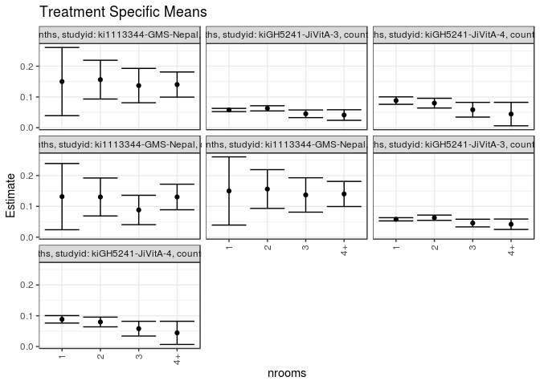

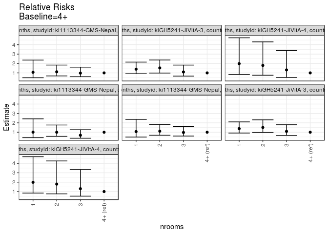

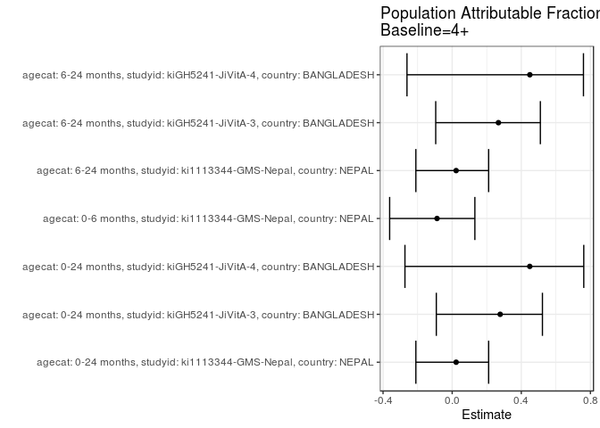

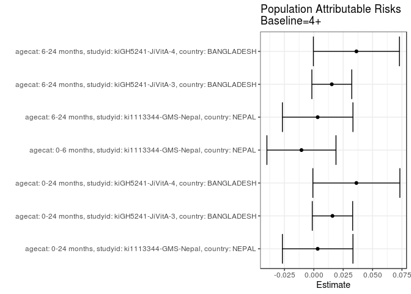

## Results Table

### Parameter: TSM

| agecat | studyid | country | intervention_level | baseline_level | estimate | ci_lower | ci_upper |
| --- | --- | --- | --- | --- | --- | --- | --- |
| 0-24 months | ki1113344-GMS-Nepal | NEPAL | 4+ | NA | 0.1402878 | 0.0994296 | 0.1811460 |
| 0-24 months | ki1113344-GMS-Nepal | NEPAL | 1 | NA | 0.1500000 | 0.0392509 | 0.2607491 |
| 0-24 months | ki1113344-GMS-Nepal | NEPAL | 2 | NA | 0.1562500 | 0.0932954 | 0.2192046 |
| 0-24 months | ki1113344-GMS-Nepal | NEPAL | 3 | NA | 0.1369863 | 0.0811668 | 0.1928058 |
| 0-24 months | kiGH5241-JiVitA-3 | BANGLADESH | 4+ | NA | 0.0412935 | 0.0241618 | 0.0584252 |
| 0-24 months | kiGH5241-JiVitA-3 | BANGLADESH | 1 | NA | 0.0577179 | 0.0525513 | 0.0628846 |
| 0-24 months | kiGH5241-JiVitA-3 | BANGLADESH | 2 | NA | 0.0630665 | 0.0546626 | 0.0714705 |
| 0-24 months | kiGH5241-JiVitA-3 | BANGLADESH | 3 | NA | 0.0453444 | 0.0329590 | 0.0577298 |
| 0-24 months | kiGH5241-JiVitA-4 | BANGLADESH | 4+ | NA | 0.0444647 | 0.0064061 | 0.0825234 |
| 0-24 months | kiGH5241-JiVitA-4 | BANGLADESH | 1 | NA | 0.0881975 | 0.0760976 | 0.1002974 |
| 0-24 months | kiGH5241-JiVitA-4 | BANGLADESH | 2 | NA | 0.0799206 | 0.0641139 | 0.0957273 |
| 0-24 months | kiGH5241-JiVitA-4 | BANGLADESH | 3 | NA | 0.0585054 | 0.0345531 | 0.0824578 |
| 0-6 months | ki1113344-GMS-Nepal | NEPAL | 4+ | NA | 0.1304348 | 0.0888976 | 0.1719719 |
| 0-6 months | ki1113344-GMS-Nepal | NEPAL | 1 | NA | 0.1315789 | 0.0240029 | 0.2391550 |
| 0-6 months | ki1113344-GMS-Nepal | NEPAL | 2 | NA | 0.1304348 | 0.0688252 | 0.1920443 |
| 0-6 months | ki1113344-GMS-Nepal | NEPAL | 3 | NA | 0.0882353 | 0.0405217 | 0.1359489 |
| 6-24 months | ki1113344-GMS-Nepal | NEPAL | 4+ | NA | 0.1402878 | 0.0994296 | 0.1811460 |
| 6-24 months | ki1113344-GMS-Nepal | NEPAL | 1 | NA | 0.1500000 | 0.0392509 | 0.2607491 |
| 6-24 months | ki1113344-GMS-Nepal | NEPAL | 2 | NA | 0.1562500 | 0.0932954 | 0.2192046 |
| 6-24 months | ki1113344-GMS-Nepal | NEPAL | 3 | NA | 0.1369863 | 0.0811668 | 0.1928058 |
| 6-24 months | kiGH5241-JiVitA-3 | BANGLADESH | 4+ | NA | 0.0418743 | 0.0249632 | 0.0587854 |
| 6-24 months | kiGH5241-JiVitA-3 | BANGLADESH | 1 | NA | 0.0579254 | 0.0527416 | 0.0631092 |
| 6-24 months | kiGH5241-JiVitA-3 | BANGLADESH | 2 | NA | 0.0631384 | 0.0546230 | 0.0716537 |
| 6-24 months | kiGH5241-JiVitA-3 | BANGLADESH | 3 | NA | 0.0457015 | 0.0332566 | 0.0581463 |
| 6-24 months | kiGH5241-JiVitA-4 | BANGLADESH | 4+ | NA | 0.0444258 | 0.0067642 | 0.0820875 |
| 6-24 months | kiGH5241-JiVitA-4 | BANGLADESH | 1 | NA | 0.0883640 | 0.0762511 | 0.1004768 |
| 6-24 months | kiGH5241-JiVitA-4 | BANGLADESH | 2 | NA | 0.0797455 | 0.0639623 | 0.0955288 |
| 6-24 months | kiGH5241-JiVitA-4 | BANGLADESH | 3 | NA | 0.0580195 | 0.0340083 | 0.0820308 |

### Parameter: E(Y)

| agecat | studyid | country | intervention_level | baseline_level | estimate | ci_lower | ci_upper |
| --- | --- | --- | --- | --- | --- | --- | --- |
| 0-24 months | ki1113344-GMS-Nepal | NEPAL | NA | NA | 0.1435811 | 0.1153098 | 0.1718524 |
| 0-24 months | kiGH5241-JiVitA-3 | BANGLADESH | NA | NA | 0.0571830 | 0.0530902 | 0.0612758 |
| 0-24 months | kiGH5241-JiVitA-4 | BANGLADESH | NA | NA | 0.0806971 | 0.0720842 | 0.0893100 |
| 0-6 months | ki1113344-GMS-Nepal | NEPAL | NA | NA | 0.1199262 | 0.0925504 | 0.1473020 |
| 6-24 months | ki1113344-GMS-Nepal | NEPAL | NA | NA | 0.1435811 | 0.1153098 | 0.1718524 |
| 6-24 months | kiGH5241-JiVitA-3 | BANGLADESH | NA | NA | 0.0571830 | 0.0530902 | 0.0612758 |
| 6-24 months | kiGH5241-JiVitA-4 | BANGLADESH | NA | NA | 0.0806971 | 0.0720842 | 0.0893100 |

### Parameter: RR

| agecat | studyid | country | intervention_level | baseline_level | estimate | ci_lower | ci_upper |
| --- | --- | --- | --- | --- | --- | --- | --- |
| 0-24 months | ki1113344-GMS-Nepal | NEPAL | 4+ | 4+ | 1.0000000 | 1.0000000 | 1.000000 |
| 0-24 months | ki1113344-GMS-Nepal | NEPAL | 1 | 4+ | 1.0692308 | 0.4834751 | 2.364660 |
| 0-24 months | ki1113344-GMS-Nepal | NEPAL | 2 | 4+ | 1.1137821 | 0.6774699 | 1.831093 |
| 0-24 months | ki1113344-GMS-Nepal | NEPAL | 3 | 4+ | 0.9764665 | 0.5917446 | 1.611315 |
| 0-24 months | kiGH5241-JiVitA-3 | BANGLADESH | 4+ | 4+ | 1.0000000 | 1.0000000 | 1.000000 |
| 0-24 months | kiGH5241-JiVitA-3 | BANGLADESH | 1 | 4+ | 1.3977489 | 0.9096588 | 2.147731 |
| 0-24 months | kiGH5241-JiVitA-3 | BANGLADESH | 2 | 4+ | 1.5272747 | 0.9817533 | 2.375921 |
| 0-24 months | kiGH5241-JiVitA-3 | BANGLADESH | 3 | 4+ | 1.0981009 | 0.6591692 | 1.829311 |
| 0-24 months | kiGH5241-JiVitA-4 | BANGLADESH | 4+ | 4+ | 1.0000000 | 1.0000000 | 1.000000 |
| 0-24 months | kiGH5241-JiVitA-4 | BANGLADESH | 1 | 4+ | 1.9835387 | 0.8304286 | 4.737826 |
| 0-24 months | kiGH5241-JiVitA-4 | BANGLADESH | 2 | 4+ | 1.7973932 | 0.7504209 | 4.305080 |
| 0-24 months | kiGH5241-JiVitA-4 | BANGLADESH | 3 | 4+ | 1.3157721 | 0.5111570 | 3.386936 |
| 0-6 months | ki1113344-GMS-Nepal | NEPAL | 4+ | 4+ | 1.0000000 | 1.0000000 | 1.000000 |
| 0-6 months | ki1113344-GMS-Nepal | NEPAL | 1 | 4+ | 1.0087719 | 0.4195072 | 2.425753 |
| 0-6 months | ki1113344-GMS-Nepal | NEPAL | 2 | 4+ | 1.0000000 | 0.5657159 | 1.767672 |
| 0-6 months | ki1113344-GMS-Nepal | NEPAL | 3 | 4+ | 0.6764706 | 0.3611643 | 1.267048 |
| 6-24 months | ki1113344-GMS-Nepal | NEPAL | 4+ | 4+ | 1.0000000 | 1.0000000 | 1.000000 |
| 6-24 months | ki1113344-GMS-Nepal | NEPAL | 1 | 4+ | 1.0692308 | 0.4834751 | 2.364660 |
| 6-24 months | ki1113344-GMS-Nepal | NEPAL | 2 | 4+ | 1.1137821 | 0.6774699 | 1.831093 |
| 6-24 months | ki1113344-GMS-Nepal | NEPAL | 3 | 4+ | 0.9764665 | 0.5917446 | 1.611315 |
| 6-24 months | kiGH5241-JiVitA-3 | BANGLADESH | 4+ | 4+ | 1.0000000 | 1.0000000 | 1.000000 |
| 6-24 months | kiGH5241-JiVitA-3 | BANGLADESH | 1 | 4+ | 1.3833151 | 0.9098908 | 2.103066 |
| 6-24 months | kiGH5241-JiVitA-3 | BANGLADESH | 2 | 4+ | 1.5078059 | 0.9786841 | 2.322995 |
| 6-24 months | kiGH5241-JiVitA-3 | BANGLADESH | 3 | 4+ | 1.0913955 | 0.6615289 | 1.800593 |
| 6-24 months | kiGH5241-JiVitA-4 | BANGLADESH | 4+ | 4+ | 1.0000000 | 1.0000000 | 1.000000 |
| 6-24 months | kiGH5241-JiVitA-4 | BANGLADESH | 1 | 4+ | 1.9890220 | 0.8397672 | 4.711078 |
| 6-24 months | kiGH5241-JiVitA-4 | BANGLADESH | 2 | 4+ | 1.7950257 | 0.7557676 | 4.263371 |
| 6-24 months | kiGH5241-JiVitA-4 | BANGLADESH | 3 | 4+ | 1.3059867 | 0.5104746 | 3.341207 |

### Parameter: PAR

| agecat | studyid | country | intervention_level | baseline_level | estimate | ci_lower | ci_upper |
| --- | --- | --- | --- | --- | --- | --- | --- |
| 0-24 months | ki1113344-GMS-Nepal | NEPAL | 4+ | NA | 0.0032933 | -0.0267198 | 0.0333064 |
| 0-24 months | kiGH5241-JiVitA-3 | BANGLADESH | 4+ | NA | 0.0158895 | -0.0012894 | 0.0330683 |
| 0-24 months | kiGH5241-JiVitA-4 | BANGLADESH | 4+ | NA | 0.0362324 | -0.0007848 | 0.0732496 |
| 0-6 months | ki1113344-GMS-Nepal | NEPAL | 4+ | NA | -0.0105086 | -0.0399030 | 0.0188858 |
| 6-24 months | ki1113344-GMS-Nepal | NEPAL | 4+ | NA | 0.0032933 | -0.0267198 | 0.0333064 |
| 6-24 months | kiGH5241-JiVitA-3 | BANGLADESH | 4+ | NA | 0.0153086 | -0.0016599 | 0.0322772 |
| 6-24 months | kiGH5241-JiVitA-4 | BANGLADESH | 4+ | NA | 0.0362713 | -0.0003379 | 0.0728804 |

### Parameter: PAF

| agecat | studyid | country | intervention_level | baseline_level | estimate | ci_lower | ci_upper |
| --- | --- | --- | --- | --- | --- | --- | --- |
| 0-24 months | ki1113344-GMS-Nepal | NEPAL | 4+ | NA | 0.0229369 | -0.2100984 | 0.2110954 |
| 0-24 months | kiGH5241-JiVitA-3 | BANGLADESH | 4+ | NA | 0.2778707 | -0.0917392 | 0.5223486 |
| 0-24 months | kiGH5241-JiVitA-4 | BANGLADESH | 4+ | NA | 0.4489922 | -0.2732519 | 0.7615479 |
| 0-6 months | ki1113344-GMS-Nepal | NEPAL | 4+ | NA | -0.0876254 | -0.3618242 | 0.1313643 |
| 6-24 months | ki1113344-GMS-Nepal | NEPAL | 4+ | NA | 0.0229369 | -0.2100984 | 0.2110954 |
| 6-24 months | kiGH5241-JiVitA-3 | BANGLADESH | 4+ | NA | 0.2677133 | -0.0952201 | 0.5103780 |
| 6-24 months | kiGH5241-JiVitA-4 | BANGLADESH | 4+ | NA | 0.4494743 | -0.2615133 | 0.7597500 |